# Analysis of Food Delivery Services

## Spring 2024 Data Science Project

### **Collaborators**: Amber Chen, Beatrice Chung, Christina Lee

**Contribution Checkpoints:**

A: Project idea - 5%

B: Dataset Curation and Preprocessing - 10%

C: Data Exploration and Summary Statistics - 10%

D: ML Algorithm Design/Development - 25%

E: ML Algorithm Training and Test Data Analysis - 20%

F: Visualization, Result Analysis, Conclusion - 15%

G: Final Tutorial Report Creation - 10%

H: Additional (not listed above, if any) - 5%

**Member 1: Amber Chen,** Contribution: 100%

**Member 2: Beatrice Chung,** Contribution: 100%

**Member 3: Christina Lee,** Contribution: 100%

"We, all team members agree together that the above information is true, and we are confident about our contributions to this submitted project/final tutorial." -- Amber Chen, Beatrice Chung, Christina Lee (5/7/2024)

**Contribution summaries:**

**Amber Chen**: Amber explored multiple datasets on Kaggle to identify a suitable dataset for the project, and all members agreed on a dataset. She contributed to data exploration and cleaning to imputate missing data. She also was responsible for performing the Mann Whitney U test to find correlation between food delivery time and restaurant rating. She also explained the steps of the final tutorial and did analysis on the ML techniques and results. She wrote the intro and did research on the effect of the pandemic on food delivery apps.

**Beatrice Chung**: Beatrice looked through a number of datasets on Kaggle to help identify the right project. She helped identify issues regarding the original data set and explanation of any issues. She was responsible for performing the Chi Squared Test for correlation between Restaurant Ratings and Cuisine. She also helped create graphs for visualization purposes. She contributed to the analysis of the ML section and writing the final insights and conclusions.

**Christina Lee**: Christina explored through a couple of datasets on Kaggle to help find a dataset that interested her and her teammates in analyzing. She helped cleaned the data by figuring out how to fill in missing ratings. Furthermore, she created visuals to help her and her teammates understand the data and trends within each field. She also performed the hypothesis testing on analyzing the correlation between rating and food preparation time and then analyzed it. Finally, she contributed to the ML analysis of classication of DT and K-Means. After all of this, she gave her insights she found in the data to make conclusions.

# Introduction

The main purpose of this project is to explain and walk through the data science lifecycle. To do this, we have chosen to explore the realm of food ordering and delivery in one of the busiest cities in the world - New York City. After the COVID pandemic, meal delivery services such as UberEats and DoorDash saw massive growth. One study found a 58% increase in food delivery transactions in the US from April 2020 to April 2021.

Why is this significant? Delivery statistics may be valuable information for restaurant owners and managers to study, since partnering with food delivery services can lead to a significant boost in sales and revenue. Food delivery services can also offer increased marketing for small restaurants. However, a restaurant that does not have a food delivery option originally would have to face challenges in packaging and sending orders, commission fees, and quality control.

After following this tutorial, we will see what factors combined receive the highest rating from customers, which restaurants can then use to determine the ideal way to generate the most revenue from food delivery services.

This dataset provides stats about the online food delivery service (**FoodHub**) demand by different restaurants in NYC. We will explore how the cuisine type, order cost, day of the week, and food preparation/delivery time impact customer rating and satisfaction and will analyze the frequency of food deliveries and draw a conclusion.

We hope to answer the following questions: How do factors such as cuisine type, food preparation delivery time impact customer rating and satisfaction?

This tutorial will step through the following:

1. Data Curation
2. Exploratory Data Analysis
3. Primary Analysis
4. Visualization
5. Insights and Conclusion

For further reading on the effect of the COVID-19 pandemic on food delivery and the restaurant industry:

1. [10 Stats That Show How COVID-19 Impacted Food Delivery Services](https://www.routific.com/10-stats-that-show-how-covid-19-impacted-food-delivery-services)
2. [Ordering in: The rapid evolution of food delivery](https://www.mckinsey.com/industries/technology-media-and-telecommunications/our-insights/ordering-in-the-rapid-evolution-of-food-delivery)

# 1. Data Curation

This is the data collection stage of the data life cycle. During this phase, we primarily focused on collecting data from websites.

Specifically in this tutorial, we will be scraping data from the Kaggle website: https://www.kaggle.com/datasets/ahsan81/food-ordering-and-delivery-app-dataset and putting this data into a dataframe for manipulation and analysis.

We will begin by importing the following Python libraries to help us collect our data:

```python
import pandas as pd
import matplotlib.pyplot as plt
import numpy as np
import seaborn as sns
import scipy
from scipy.stats import f_oneway
from scipy.stats import chi2_contingency
from scipy import stats
import warnings
warnings.filterwarnings("ignore")
```

Now, we retrieve the data from the dataset and store it in a Dataframe called df. We do this by using the **pd.read_csv()** function.

A **Dataframe** is a 2D labeled data structure that represents data in a tabular format, similar to a spreadsheet or SQL table. Each column in a dataframe can have a different data type, and we will perform various operations like filtering, grouping, merging, and aggregation on the data to test hypotheses throughout this tutorial.

After storing the data in the Dataframe, we convert all data types to the correct representation for data pre-processing. For example, we updated the **'rating'** column by first checking the data type and then converting it to float64 for a mathematical representation. Thus, we could identify the data that is missing when it was represented as **NaN**.

Printed below is the **head** of the resulting Dataframe using **df.head()**.

```python
df = pd.read_csv("food_order.csv")

df

# check if cols are in the right type
# print(df.dtypes)

# convert rating col to float64
# now "Not given" is rep as NaN
df['rating'] = pd.to_numeric(df['rating'], errors='coerce')
print(df.dtypes)

num_rows, num_columns = df.shape
df.head()
```

```
order_id                   int64
customer_id                int64
restaurant_name           object
cuisine_type              object
cost_of_the_order        float64
day_of_the_week           object
rating                   float64
food_preparation_time      int64
delivery_time              int64
dtype: object
```

|  | order_id | customer_id | restaurant_name | cuisine_type | cost_of_the_order | day_of_the_week | rating | food_preparation_time | delivery_time |
| --- | --- | --- | --- | --- | --- | --- | --- | --- | --- |
| 0 | 1477147 | 337525 | Hangawi | Korean | 30.75 | Weekend | NaN | 25 | 20 |
| 1 | 1477685 | 358141 | Blue Ribbon Sushi Izakaya | Japanese | 12.08 | Weekend | NaN | 25 | 23 |
| 2 | 1477070 | 66393 | Cafe Habana | Mexican | 12.23 | Weekday | 5.0 | 23 | 28 |
| 3 | 1477334 | 106968 | Blue Ribbon Fried Chicken | American | 29.20 | Weekend | 3.0 | 25 | 15 |
| 4 | 1478249 | 76942 | Dirty Bird to Go | American | 11.59 | Weekday | 4.0 | 25 | 24 |

When performing **data cleaning**, we mapped each of the values in cost_of_the_order into a range from $0 - $10, $10 - $20, $20 - $30, and $30 - $40 to categorize this data. This was done so that we could fill in the missing values found in the rating column through imputation. We found rows with the same cuisine_type and group_order_cost to impute the missing rating data.

```python
def map_to_range(cost):
    if cost <= 10:
        return '$0 - $10'
    elif cost <= 20:
        return '$10 - $20'
    elif cost <= 30:
        return '$20 - $30'
    else:
        return '$30 - $40'

# Apply the function to create a new column
df['group_order_cost'] = df['cost_of_the_order'].apply(map_to_range)
```

We also dropped any NaN values in the "rating" column to further **clean the data** as this data is not relevant to the data analysis of this dataset as a whole.

We are now done **cleaning the data**!! Examine the head of the Dataframe below.

```python
# Replace NaN values in the "rating" column based on similar rows
for index, row in df.iterrows():
    if np.isnan(row['rating']):
        similar_rows = df[(df['group_order_cost'] == row['group_order_cost']) & (df['cuisine_type'] == row['cuisine_type'])]
        similar_ratings = similar_rows[similar_rows['rating'].notna()]['rating']
        if not similar_ratings.empty:
            df.loc[index, 'rating'] = similar_ratings.mode()[0]

# drop any NaN for extra cleaning
df = df.dropna(subset=['rating'])
# reset the index
df = df.reset_index(drop=True)

df.head()
```

|  | order_id | customer_id | restaurant_name | cuisine_type | cost_of_the_order | day_of_the_week | rating | food_preparation_time | delivery_time | group_order_cost |
| --- | --- | --- | --- | --- | --- | --- | --- | --- | --- | --- |
| 0 | 1477685 | 358141 | Blue Ribbon Sushi Izakaya | Japanese | 12.08 | Weekend | 5.0 | 25 | 23 | $10 - $20 |
| 1 | 1477070 | 66393 | Cafe Habana | Mexican | 12.23 | Weekday | 5.0 | 23 | 28 | $10 - $20 |
| 2 | 1477334 | 106968 | Blue Ribbon Fried Chicken | American | 29.20 | Weekend | 3.0 | 25 | 15 | $20 - $30 |
| 3 | 1478249 | 76942 | Dirty Bird to Go | American | 11.59 | Weekday | 4.0 | 25 | 24 | $10 - $20 |
| 4 | 1477224 | 147468 | Tamarind TriBeCa | Indian | 25.22 | Weekday | 3.0 | 20 | 24 | $20 - $30 |

# 2. Exploratory Data Analysis

During the exploratory analysis stage of the data life cycle, we attempt to observe potential trends in our data. We will perform statistical analyses throughout this step to observe evidence for potential trends.

### Preliminary Data Analysis

Upon examining the categorical variables, we can see the top 10 restaurants that receive the most orders.

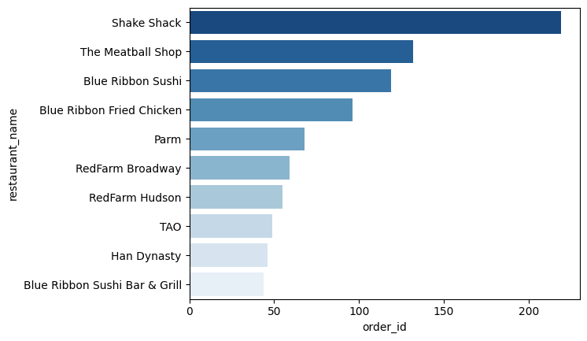

```python
restaurant = df[['restaurant_name','order_id']].groupby('restaurant_name').agg('count').sort_values('order_id', ascending=False).reset_index()
sns.barplot(data=restaurant.head(10), x="order_id", y="restaurant_name")

custom_palette = sns.color_palette("Blues_r", 10)  # You can choose any palette from seaborn or specify your own

# Create the bar plot with the custom palette
sns.barplot(data=restaurant.head(10), x="order_id", y="restaurant_name", palette=custom_palette)

# Show the plot
plt.show()
```

From these top ten restaurants, let's see their distributions of ratings.

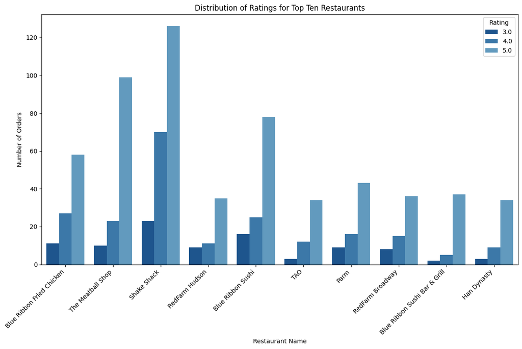

```python
top_restaurants = df[df['restaurant_name'].isin(restaurant['restaurant_name'].head(10))]

# create a custom pretty color palette with distinct colors for each rating
custom_palette = sns.color_palette("Blues_r", 6)

# create a bar plot for each restaurant showing the distribution of ratings with the custom palette
plt.figure(figsize=(12, 8))
sns.countplot(data=top_restaurants, x='restaurant_name', hue='rating', palette=custom_palette)
plt.xlabel('Restaurant Name')
plt.ylabel('Number of Orders')
plt.title('Distribution of Ratings for Top Ten Restaurants')
plt.xticks(rotation=45, ha='right')
plt.legend(title='Rating')
plt.tight_layout()
plt.show()
```

We can see that Shake Shack had the most 5 star ratings, followed by The Meatball Shop and Blue Ribbon Sushi.

We can see that for all top ten restaurants, rating of 5 always had the highest frequency then rating of 4 and then rating of 3. This indicates that the restaurant name does not have a correlation on the rating.

Now let's look at our other categorical variable, cuisine type and look at the frequency of the top ten cuisines.

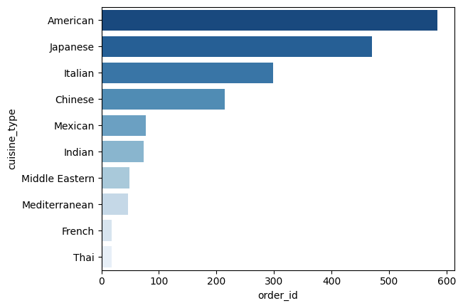

```python
restaurant = df[['cuisine_type','order_id']].groupby('cuisine_type').agg('count').sort_values('order_id', ascending=False).reset_index()
sns.barplot(data=restaurant.head(10), x="order_id", y="cuisine_type")

custom_palette = sns.color_palette("Blues_r", 10)  # You can choose any palette from seaborn or specify your own

# Create the bar plot with the custom palette
sns.barplot(data=restaurant.head(10), x="order_id", y="cuisine_type", palette=custom_palette)

# Show the plot
plt.show()
```

Let's also examine the top cuisines as distributed by ratings.

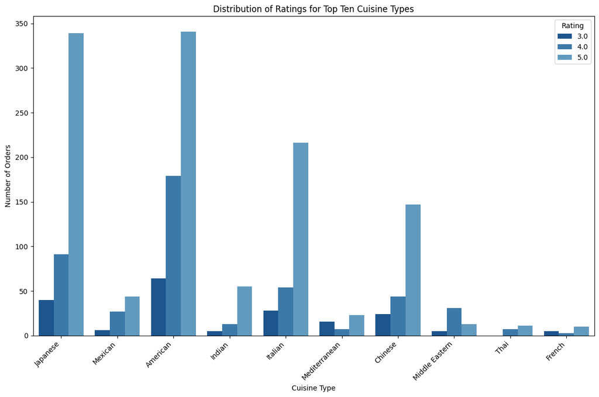

```python
top_restaurants = df[df['cuisine_type'].isin(restaurant['cuisine_type'].head(10))]

# create a custom pretty color palette with distinct colors for each rating
custom_palette = sns.color_palette("Blues_r", 6)

# create a bar plot for each restaurant showing the distribution of ratings with the custom palette
plt.figure(figsize=(12, 8))
sns.countplot(data=top_restaurants, x='cuisine_type', hue='rating', palette=custom_palette)
plt.xlabel('Cuisine Type')
plt.ylabel('Number of Orders')
plt.title('Distribution of Ratings for Top Ten Cuisine Types')
plt.xticks(rotation=45, ha='right')
plt.legend(title='Rating')
plt.tight_layout()
plt.show()
```

Now, let's look at the frequency of our numeric features: cost of order, food preparation time and delivery time.

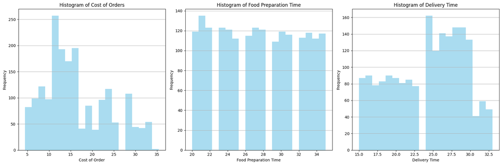

```python
import matplotlib.pyplot as plt

# Set up subplots
fig, axs = plt.subplots(1, 3, figsize=(18, 6))

# Histogram for Cost of Order
axs[0].hist(df['cost_of_the_order'], bins=20, color='skyblue', alpha=0.7)
axs[0].set_xlabel('Cost of Order')
axs[0].set_ylabel('Frequency')
axs[0].set_title('Histogram of Cost of Orders')
axs[0].grid(axis='y')

# Histogram for Food Preparation Time
axs[1].hist(df['food_preparation_time'], bins=20, color='skyblue', alpha=0.7)
axs[1].set_xlabel('Food Preparation Time')
axs[1].set_ylabel('Frequency')
axs[1].set_title('Histogram of Food Preparation Time')
axs[1].grid(axis='y')

# Histogram for Delivery Time
axs[2].hist(df['delivery_time'], bins=20, color='skyblue', alpha=0.7)
axs[2].set_xlabel('Delivery Time')
axs[2].set_ylabel('Frequency')
axs[2].set_title('Histogram of Delivery Time')
axs[2].grid(axis='y')

# Adjust layout
plt.tight_layout()

# Show the plots
plt.show()
```

Now let's create some scatter plots for these three features to see their correlation with rating.

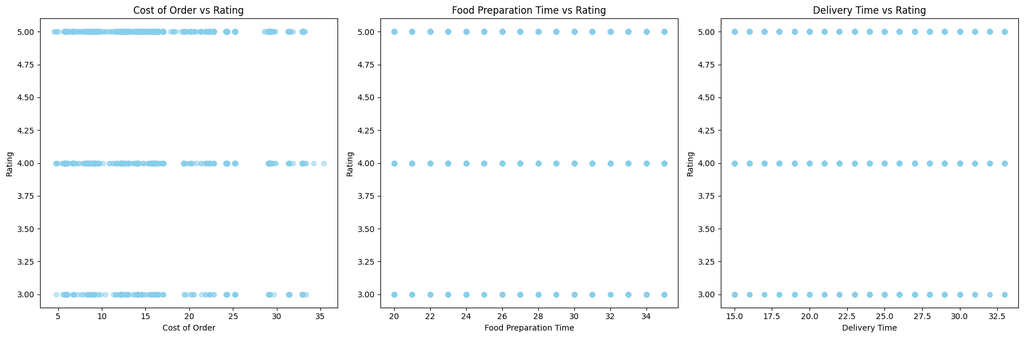

```python
fig, axs = plt.subplots(1, 3, figsize=(18, 6))

# Scatter plot for Cost of Order vs Rating
axs[0].scatter(df['cost_of_the_order'], df['rating'], color='skyblue', alpha=0.5)
axs[0].set_xlabel('Cost of Order')
axs[0].set_ylabel('Rating')
axs[0].set_title('Cost of Order vs Rating')

# Scatter plot for Food Preparation Time vs Rating
axs[1].scatter(df['food_preparation_time'], df['rating'], color='skyblue', alpha=0.5)
axs[1].set_xlabel('Food Preparation Time')
axs[1].set_ylabel('Rating')
axs[1].set_title('Food Preparation Time vs Rating')

# Scatter plot for Delivery Time vs Rating
axs[2].scatter(df['delivery_time'], df['rating'], color='skyblue', alpha=0.5)
axs[2].set_xlabel('Delivery Time')
axs[2].set_ylabel('Rating')
axs[2].set_title('Delivery Time vs Rating')

plt.tight_layout()
plt.show()
```

As you can see, no matter the cost of the order, food preparation time, or delivery time, the scatter plot for rating 3, 4, or 5 look the same. Thus there is no correlation.

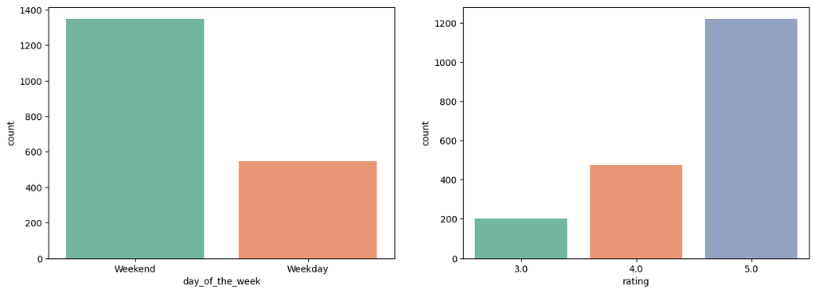

```python
plt.figure(figsize = (15,5))

plt.subplot(1,2,1)
sns.countplot(x = 'day_of_the_week', palette='Set2', data = df)

plt.subplot(1,2,2)
sns.countplot(x = 'rating', palette='Set2', data = df)
```

## Hypothesis Testing

We can not guarantee based on the previous graphs and data exploratory analysis that there is no correlation between the cost of the order vs rating, nor food preparation vs rating. We also can't guarantee that there is some correlation between cuisine type vs rating. Thus, let's perform some **hypothesis testing** on the delivery time, food preparation time, and cuisine to see if there is a significant difference in ratings based on these features.

### A. Examining Restaurant Ratings and Delivery TIme

For example, we will first examine the following hypotheses: What is the statistical difference in restaurant ratings between the two delivery time groups? We did so by performing a **Mann Whitney U test** and examining the resulting box plots. However, we can see that from the resulting box plots, the resulting p-value was greater than 0.05 so we fail to reject the Null hypothesis.

We choose to use a **Mann Whitney U test** because we want to compare two independent groups. We will use the Mann-Whitne U test to analyze the difference in central tendancies between two groups.

To perform the Hypothesis Testing, we must create our hypotheses! Let's call H0 the Null Hypothesis and HA the Alternate Hypothesis. The Null Hypothesis states that there is no relationship between groups. The Alternative Hypothesis states that there is a relationship between groups.

`H0: There is no difference in restaurant ratings between the two delivery time groups.`

`HA: There is a significant difference in restaurant ratings between the two delivery time groups.`

```
Threshold: 24.162447257383967
P-value: 0.6513679772245431
We fail to reject the null hypothesis because the p-value is greater than the significance value of 0.05.
```

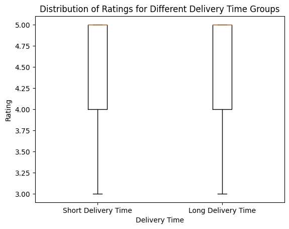

```python
# divide delivery time into two groups
# find the threshold by finding mean of delivery time
threshold = df['delivery_time'].mean()
print("Threshold:", threshold)

short_time = df[df['delivery_time'] <= threshold]
long_time = df[df['delivery_time'] > threshold]
data = [short_time['rating'], long_time['rating']]

# we perform a Mann Whitney U test because we do not know if the two variables are normally distributed
statistic, p_value = scipy.stats.mannwhitneyu(short_time['rating'], long_time['rating'])
print("P-value:", p_value)

# since p_value > alpha, we fail to reject
print("We fail to reject the null hypothesis because the p-value is greater than the significance value of 0.05.")

# graph the relationship btwn delivery time and rating
plt.boxplot(data, labels=['Short Delivery Time', 'Long Delivery Time'])
plt.xlabel('Delivery Time')
plt.ylabel('Rating')
plt.title('Distribution of Ratings for Different Delivery Time Groups')
plt.show()
```

### B. Examining Restaurant Ratings and Food Preparation Time

Next, we will examine the following hypotheses:

- What is the statistical difference in restaurant ratings between the food preparation time?

`H0: Food preparation time has no effect on the rating of the restaurant.`

`HA: Food preparation time has a significant effect on the rating of the restaurant.`

We will perform an ANOVA test because there are multiple groups. The groups are ranges (increments of 5) in food_preparation_time.

```python
# group the data based on food preparation time ranges
group_20_25 = df[(df['food_preparation_time'] >= 20) & (df['food_preparation_time'] < 25)]['rating']
group_25_30 = df[(df['food_preparation_time'] >= 25) & (df['food_preparation_time'] < 30)]['rating']
group_30_35 = df[(df['food_preparation_time'] >= 30) & (df['food_preparation_time'] < 35)]['rating']
group_35_40 = df[(df['food_preparation_time'] >= 35) & (df['food_preparation_time'] < 40)]['rating']

# perform ANOVA test!
f_statistic, p_value = f_oneway(group_20_25, group_25_30, group_30_35, group_35_40)

# results
print(f"F-statistic: {f_statistic}")
print(f"P-value: {p_value}")

# interpret
alpha = 0.05

print("\nConclusion: ")
if p_value < alpha:
    print("Reject the null hypothesis. \nFood preparation time has a significant effect on restaurant ratings.")
else:
    print("Fail to reject the null hypothesis. \nThere is no significant effect of food preparation time on restaurant ratings.")
```

```
F-statistic: 1.5423438685415842
P-value: 0.2016115750201814

Conclusion:
Fail to reject the null hypothesis.
There is no significant effect of food preparation time on restaurant ratings.
```

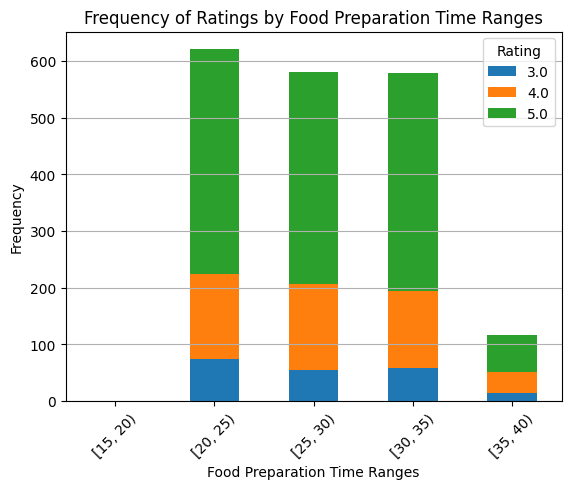

```python
# group food_preparation_times into ranges
time_ranges = [15, 20, 25, 30, 35, 40]

# create a new column 'time_range' based on the smaller time ranges
df['time_range'] = pd.cut(df['food_preparation_time'], bins=time_ranges, right=False)

# group by 'time_range' and 'rating' to get the frequency of each rating within each time range
grouped_data = df.groupby(['time_range', 'rating']).size().unstack(fill_value=0)

# plotting the bar graph
plt.figure(figsize=(12, 8))
grouped_data.plot(kind='bar', stacked=True)
plt.title('Frequency of Ratings by Food Preparation Time Ranges')
plt.xlabel('Food Preparation Time Ranges')
plt.ylabel('Frequency')
plt.xticks(rotation=45)
plt.legend(title='Rating')
plt.grid(axis='y')
plt.show()
```

### C. Examining Restaurant Ratings and Cusine

Lastly, we will first examine the following hypotheses:

- What is the statistical difference in restaurant ratings between the cusine type?

`H0: The cuisine has no effect on the rating of the restaurant.`

`HA: The cuisine has a significant effect on the rating of the restaurant.`

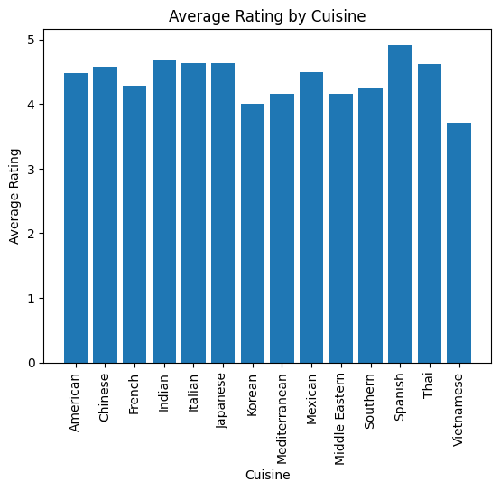

```
Chi-square statistic: 162.38746860352413
p-value: 1.0973520346826067e-21
Reject the null hypothesis: Cuisine has a significant effect on restaurant ratings.
```

```python
# code for hypothesis testing 3
# Calculate the average rating for each level of group_order_cost
avg_rating = df.groupby('cuisine_type')['rating'].mean().reset_index()

# Create the bar chart
plt.bar(avg_rating['cuisine_type'], avg_rating['rating'])
plt.xlabel('Cuisine')
plt.ylabel('Average Rating')
plt.title('Average Rating by Cuisine')
plt.xticks(rotation=90)

plt.show()

# Create a contingency table (cross-tabulation) of 'cuisine_type' and 'rating'
contingency_table = pd.crosstab(df['cuisine_type'], df['rating'])

# Perform chi-square test to examine if there is a significant association between two categorical variables.
# We can assume that this data is categorical and is collected through independent observations.
chi2_stat, p_value, dof, expected = chi2_contingency(contingency_table)

# results
print("Chi-square statistic:", chi2_stat)
print("p-value:", p_value)

# interpret
alpha = 0.05  # Significance level
if p_value < alpha:
    print("Reject the null hypothesis: Cuisine has a significant effect on restaurant ratings.")
else:
    print("Fail to reject the null hypothesis: There is no significant effect of cuisine on restaurant ratings.")
```

# 3. Primary Analysis

## Machine Learning Technique: Classification (Decision Tree)

We want to see if we can predict the rating based on knowing the cost of the order, food preparation time, and cuisine type. We will do this by performing classification, specifically, making a decision tree.

```python
import pandas as pd
from sklearn.model_selection import train_test_split
from sklearn.preprocessing import OneHotEncoder
from sklearn.tree import DecisionTreeClassifier, plot_tree
import matplotlib.pyplot as plt
from sklearn.metrics import accuracy_score, classification_report


# features are cost, food prep, and cuisine
# (through hypothesis testing we found that delivery time had no impact on rating)
X = df[['cost_of_the_order', 'food_preparation_time', 'cuisine_type']]

# target var (what we want to predict) is rating
y = df['rating']

# cost and food prep are numeric, however, cuisine type is categorical
# thus have to perform one-hot encoding for cuisine type

# note we set sparse = False to get an arr instead of a sparse matrix
encoder = OneHotEncoder(sparse = False)
X_encoded = encoder.fit_transform(X[['cuisine_type']])
X_encoded_df = pd.DataFrame(X_encoded, columns=encoder.categories_[0])

X = pd.concat([X[['cost_of_the_order', 'food_preparation_time']], X_encoded_df], axis=1)

# now split data into training and testing sets
X_train, X_test, y_train, y_test = train_test_split(X, y, test_size=0.2, random_state=42)

# we will be doing DT for classication
clf = DecisionTreeClassifier(random_state=42)
clf.fit(X_train, y_train)

# predicted ratings for the test set
y_pred = clf.predict(X_test)

# eval our model's performance
accuracy = accuracy_score(y_test, y_pred)
report = classification_report(y_test, y_pred)

print("Accuracy:", accuracy)
print("Classification Report:\n", report)
```

```
Accuracy: 0.4868421052631579
Classification Report:
               precision    recall  f1-score   support

         3.0       0.12      0.15      0.13        41
         4.0       0.24      0.24      0.24       101
         5.0       0.67      0.65      0.66       238

    accuracy                           0.49       380
   macro avg       0.34      0.35      0.34       380
weighted avg       0.50      0.49      0.49       380
```

## Machine Learning Technique: Classication (K-Means)

We then thought that perhaps classifying the data points into ratings of 3, 4, and 5 aren’t the correct labels. We wanted to see if there are better labels to classify our data points into, thus we performed another classification technique, K-Means. We tried to classify our data points into three categories based on the features of food preparation time and cost of the order.

```python
import pandas as pd
from sklearn.preprocessing import StandardScaler
from sklearn.cluster import KMeans

selected_features = ['food_preparation_time', 'cost_of_the_order']

scaler = StandardScaler()
df_scaled = scaler.fit_transform(df[selected_features])

# we will perform K-means
num_clusters = 3 # 3 clusters because the ratings were mostly 3, 4, 5
kmeans = KMeans(n_clusters = num_clusters, random_state = 0)

clusters = kmeans.fit_predict(df_scaled)

df['cluster'] = clusters

# calculate the center for each cluster
cluster_centers = pd.DataFrame(scaler.inverse_transform(kmeans.cluster_centers_), columns=selected_features)
print(cluster_centers)
```

```
   food_preparation_time  cost_of_the_order
0              23.387275          12.343292
1              27.481905          26.720438
2              31.722222          12.806651
```

# 4. Visualization

## Visualization of Decision Tree

We can visualize the Decision Tree algorithm result through a decision tree.

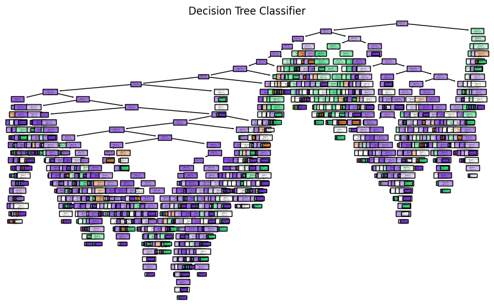

```python
# Plot the decision tree
plt.figure(figsize=(10, 6))
plot_tree(clf, filled=True, feature_names=X.columns, class_names=['3.0', '4.0', '5.0'])
plt.title("Decision Tree Classifier")
plt.show()
```

## Visualization of K-Means

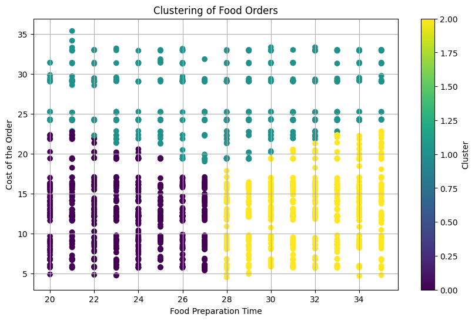

```python
# plot clustering graph
plt.figure(figsize=(10, 6))
plt.scatter(df['food_preparation_time'], df['cost_of_the_order'], c=df['cluster'], cmap='viridis')
plt.xlabel('Food Preparation Time')
plt.ylabel('Cost of the Order')
plt.title('Clustering of Food Orders')
plt.colorbar(label='Cluster')
plt.grid(True)
plt.show()
```

The points are scattered everywhere indicating that there is no correlation between food preparation time and cost of the order. As you can see the clusters do not really mean anything.

# 5. Insights and Policy Decisions

After performing necessary data cleaning, the dataset contains 1,898 entries with 10 features. Of these 10 features, we chose to examine the effect of delivery time, food preparation time, cuisine type, and cost of order on the rating. When making "policy" decisions or "goals" for the app, we want to analyze what feature has the most impact on customer ratings to improve overall usage of the **FoodHub app**. This will create better business for customers and restaurants.

After performing Exploratory Data Analysis and Hypothesis Testing, we can conclude that only the Cuisine has an impact on the Restaurant Ratings.

From the Decision Tree, we see that the tree is extremely complex. We concluded that the reason for this is because there is no correlation between cost of the order and rating, along with no correlation between food preparation time and rating. This is why the decision tree had an accuracy of less than 50%.

The insights of performing these ML techniques on our data agreed with the insights we found from performing Exploration Data Analysis and Hypothesis Testing that cost of order and food prearation do not have an effect on restaurant ratings.

Thus, out of the 10 features, Cuisine has the most impact, most correlation, and most effect on the Restaurant Rating.